# HW_27_09

Load libraries and data

```r
library(tidyverse)
library(factoextra)
library(viridis)
mall <- read_csv("mall_customers.csv")
```

```r
# adjust names and change sex to num as categ not used in k means.
# havent scaled as numbers kind of close

mall <- mall %>%
  rename(annual_income = "Annual Income (k$)",
         spend_score = "Spending Score (1-100)") %>%
  mutate(Gender = as.factor(if_else(Gender == "Male",1,0 )))

mall <- janitor::clean_names(mall) %>%
  select(-customer_id)


mall_scale <- mall %>%
  select(spend_score, annual_income) %>%
  mutate(across(where(is.numeric),scale))
```

# Task 1

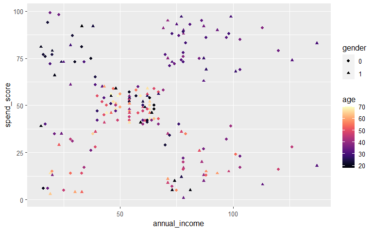

```r
mall %>%
  ggplot(aes(x = annual_income, y = spend_score, color = age, shape = gender)) +
  geom_point() +
  scale_color_viridis(option = "magma")
```

# Task 2

```r
library(broom)

#define max k
max_k <- 15


clustered_data <- kmeans(mall_scale %>%                            select(spend_score,annual_income),
                         centers = 4,
                         nstart = 25)


glance(clustered_data)
```

| totss | tot.withinss | betweenss | iter |
| --- | --- | --- | --- |
| 398 | 108.3767 | 289.6233 | 2 |

```r
k_clusters <- tibble(k = 1:max_k)

clustered_k <- k_clusters %>%
  mutate(
    kclust = map(k, ~kmeans(mall_scale %>% select(spend_score, annual_income), centers = .x, nstart = 25)),
    glanced = map(kclust, glance),
    augmented = map(kclust, augment, mall),
  )
```

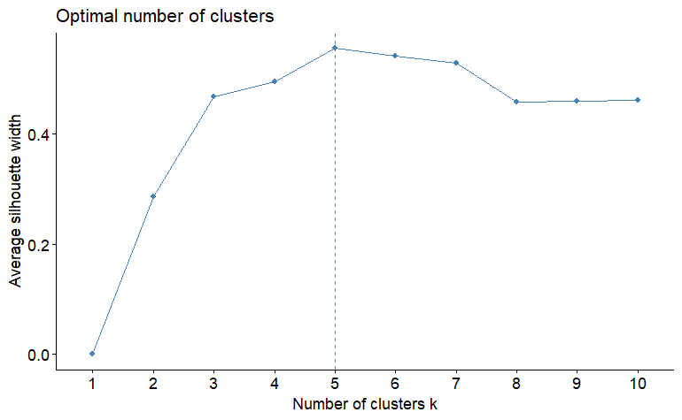

```r
fviz_nbclust(mall_scale, kmeans, method = "silhouette", nstart = 25)
```

5 clusters seems best number.

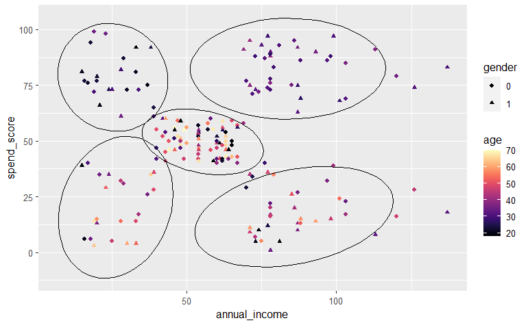

```r
clustered_k %>%
  filter(k == 5) %>%
  unnest(augmented) %>%
  ggplot(aes(y = spend_score, x = annual_income, colour = age, shape = gender)) +
           geom_point() +
  stat_ellipse(aes(group = .cluster)) +
  scale_color_viridis(option = "magma"
  )
```

Ellipses show clear clustered groups, 5 appears to be solid number.

(males are triangle)

Top right cluster: younger, wealthier group. Young professionals with more cash appear willing to spend. Mix of male and female.

Bottom right, older, wealthier, mainly men, have higher incomes but less likely to spend.

Middle cluser: diverse mix of gender and age, average income and average spend, more likely to buy middle priced items. Little luxuries.

Top left: lower income but big speders. Mainly younger population with little experience that blow what little cash they have.

Bottom left: older group with little income, probably on pensions, not likely to spend much.